# STAC32 Assignment 6 - 1002244252 (Stephen Pereira

```r
library(tidyverse)
```

13.a) We read the data in:

```r
url = "https://www.utsc.utoronto.ca/~butler/c32/texmex.txt"
cars = read_delim(url, " ")
cars
```

| I | II | III | IV | V |
| --- | --- | --- | --- | --- |
| 44 | 412 | 237 | 518 | 367 |
| 382 | 441 | 390 | 501 | 445 |
| 353 | 607 | 365 | 577 | 480 |
| 395 | 531 | 355 | 642 | 323 |
| 207 | 486 | 217 | 489 | 366 |
| 312 | 508 | 268 | 475 | 325 |
| 407 | 337 | 117 | 532 | 316 |
| 421 | 419 | 273 | 540 | 381 |
| 366 | 499 | 288 | NA | 407 |
| 222 | 387 | 351 | NA | 339 |

| I <int> | II <int> | III <int> | IV <int> | V <int> |
| --- | --- | --- | --- | --- |
| 44 | 412 | 237 | 518 | 367 |
| 382 | 441 | 390 | 501 | 445 |
| 353 | 607 | 365 | 577 | 480 |
| 395 | 531 | 355 | 642 | 323 |
| 207 | 486 | 217 | 489 | 366 |
| 312 | 508 | 268 | 475 | 325 |
| 407 | 337 | 117 | 532 | 316 |
| 421 | 419 | 273 | 540 | 381 |
| 366 | 499 | 288 | NA | 407 |
| 222 | 387 | 351 | NA | 339 |

1-10 of 10 rows

We have the 5 locations as columns, and 10 observations for each (except location 4, we have 8)

2. Our data is not tidy, as we need one column for the number of cars observed and one for their respective location in order to analyze using ANOVA. We also have 2 NA entries.
3. We make our tidy data frame using the tidyverse function `gather`:

```r
# We remove the NA observations as well.
cars_tidy <- (cars %>% gather(Location, Cars_Observed,I:V,na.rm =T))
cars_tidy
```

|  | Location | Cars_Observed |
| --- | --- | --- |
| 1 | I | 44 |
| 2 | I | 382 |
| 3 | I | 353 |
| 4 | I | 395 |
| 5 | I | 207 |
| 6 | I | 312 |
| 7 | I | 407 |
| 8 | I | 421 |
| 9 | I | 366 |
| 10 | I | 222 |

[output cut: 38 more lines]

|  | Location <chr> | Cars_Observed <int> |  |  |
| --- | --- | --- | --- | --- |
| 1 | I | 44 |  |  |
| 2 | I | 382 |  |  |
| 3 | I | 353 |  |  |
| 4 | I | 395 |  |  |
| 5 | I | 207 |  |  |
| 6 | I | 312 |  |  |
| 7 | I | 407 |  |  |
| 8 | I | 421 |  |  |
| 9 | I | 366 |  |  |
| 10 | I | 222 |  |  |

1-10 of 48 rows

4. We make a box plot:

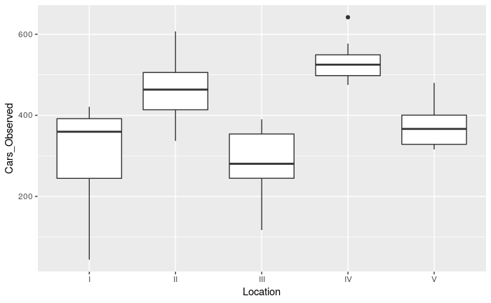

```r
ggplot(cars_tidy, aes(x=Location, y=Cars_Observed))+geom_boxplot()
```

5. We have an outlier and the spreads are unequal. We run ANOVA:

```r
cars_ANOVA = aov(Cars_Observed~Location,data=cars_tidy)
summary(cars_ANOVA)
```

```
            Df Sum Sq Mean Sq F value   Pr(>F)
Location     4 391909   97977   14.34 1.63e-07 ***
Residuals   43 293888    6835
---
Signif. codes:  0 ‘***’ 0.001 ‘**’ 0.01 ‘*’ 0.05 ‘.’ 0.1 ‘ ’ 1
```

With a p-value of 1.63*10^-7 (Which is very much below 0.05) we reject the null that the means for all locations are the same.

6. Although we have unequal spreads and an outlier, we run Tukey’s test because we got a significant result:

```r
TukeyHSD(cars_ANOVA)
```

```
  Tukey multiple comparisons of means
    95% family-wise confidence level

Fit: aov(formula = Cars_Observed ~ Location, data = cars_tidy)

$Location
          diff        lwr       upr     p adj
II-I    151.80   46.54516 257.05484 0.0015822
III-I   -24.80 -130.05484  80.45484 0.9616384
IV-I    223.35  111.71039 334.98961 0.0000097
V-I      64.00  -41.25484 169.25484 0.4263740
III-II -176.60 -281.85484 -71.34516 0.0001957
IV-II    71.55  -40.08961 183.18961 0.3731687
V-II    -87.80 -193.05484  17.45484 0.1419592
IV-III  248.15  136.51039 359.78961 0.0000012
V-III    88.80  -16.45484 194.05484 0.1343769
V-IV   -159.35 -270.98961 -47.71039 0.0017972
```

7. Based on the tests we’ve run, I-II, IV-I, III-II, IV-III, V-IV are significant. Almost all differences involving IV are significant, and from the box plot we can also see that it has the highest box for cars observed. II also seems like a good location based on Tukey and the box plot. So overall I would recommend location IV and possibly location II for the franchise.

# Exploring the Winning Times of Runners in the Boston Marathon: Are They Increasing?

### Introduction

The purpose of this report is to test if the winning times for runners in the Boston Marathon have been increasing, and to what degree. We will use winning times from 1897 to 2018, as well as the gender of the individual running in order to conduct our analysis. In order to ease the processing of data, we will be using `Tidyverse`. In our analysis, we hope to see if they winning times are following some sort of trend, and if the trend differs based on gender.

### The Data Obtained

The following is the data being used to conduct the analysis. We have the gender of the individual who won, the year in which they won and their winning time. We have data for men from 1897 until 2018, and data for women from 1966 to 2018. The data is organized into three columns: `Gender`, `Year` and `WinTime`. We have 176 rows of data. The `WinTime` is a decimal representation of the winners time.

```r
# We store the url in a variable
url_bm <- "https://www.utsc.utoronto.ca/~butler/c32/marathon.csv"
# Using the tidyverse function to read the csv
winning_times <- read_csv(url_bm)
winning_times
```

| Gender | Year | WinTime |
| --- | --- | --- |
| Men | 1897 | 2.919444 |
| Men | 1898 | 2.700000 |
| Men | 1899 | 2.910556 |
| Men | 1900 | 2.662222 |
| Men | 1901 | 2.489722 |
| Men | 1902 | 2.720000 |
| Men | 1903 | 2.691389 |
| Men | 1904 | 2.634444 |
| Men | 1905 | 2.640278 |
| Men | 1906 | 2.762500 |

[output cut: 166 more lines]

| Gender <chr> | Year <int> | WinTime <dbl> |  |  |
| --- | --- | --- | --- | --- |
| Men | 1897 | 2.919444 |  |  |
| Men | 1898 | 2.700000 |  |  |
| Men | 1899 | 2.910556 |  |  |
| Men | 1900 | 2.662222 |  |  |
| Men | 1901 | 2.489722 |  |  |
| Men | 1902 | 2.720000 |  |  |
| Men | 1903 | 2.691389 |  |  |
| Men | 1904 | 2.634444 |  |  |
| Men | 1905 | 2.640278 |  |  |
| Men | 1906 | 2.762500 |  |  |

1-10 of 176 rows

If we wish to view the winning times for the woman’s marathon, we can do so by filtering:

```r
winning_times %>% filter(Gender=="Women")
```

| Gender | Year | WinTime |
| --- | --- | --- |
| Women | 1966 | 3.361111 |
| Women | 1967 | 3.454722 |
| Women | 1968 | 3.500000 |
| Women | 1969 | 3.379444 |
| Women | 1970 | 3.085278 |
| Women | 1971 | 3.141667 |
| Women | 1972 | 3.173889 |
| Women | 1973 | 3.099722 |
| Women | 1974 | 2.786389 |
| Women | 1975 | 2.706667 |

[output cut: 44 more lines]

| Gender <chr> | Year <int> | WinTime <dbl> |  |  |
| --- | --- | --- | --- | --- |
| Women | 1966 | 3.361111 |  |  |
| Women | 1967 | 3.454722 |  |  |
| Women | 1968 | 3.500000 |  |  |
| Women | 1969 | 3.379444 |  |  |
| Women | 1970 | 3.085278 |  |  |
| Women | 1971 | 3.141667 |  |  |
| Women | 1972 | 3.173889 |  |  |
| Women | 1973 | 3.099722 |  |  |
| Women | 1974 | 2.786389 |  |  |
| Women | 1975 | 2.706667 |  |  |

1-10 of 54 rows

By filtering we can see that women have had a separate marathon since 1966, and we have winning times for them from then to 2018.

### Plotting the Data

In order to observe any trend, we plot the data on a scatter plot. We will distinguish the men and women winning times by colour:

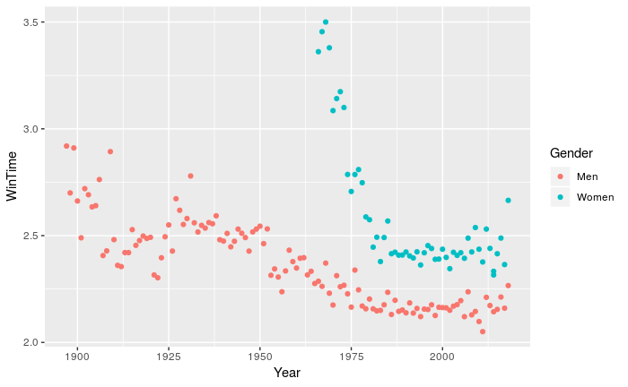

```r
ggplot(winning_times, aes(x=Year,y=WinTime, colour=Gender))+geom_point()
```

From the scatter plot we can see that `WinTime` for both men and women have been generally decreasing. It seems that the rate of decrease has been decreasing from 1975 onwards. Based on the plotted data, we conclude that the winning times for the Boston Marathon has been going down (Faster times) for both genders.

We now focus on the times for women. We filter the scatter plot to only display the woman’s winning times and fit a straight line on it’s plot:

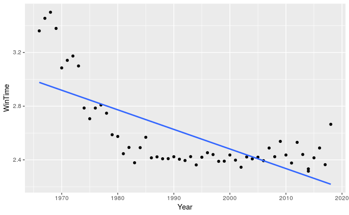

```r
ggplot(winning_times %>% filter(Gender=="Women"), aes(x=Year,y=WinTime))+geom_point()+geom_smooth(method="lm", se=F)
```

From the plot above we can see that the decrease in winning times is not linear, and does not follow the line. It is not a good predictor for winning times at all, as it predicts winning time for 2018 would be around 2.2, when it is around 2.6 instead. A better line would follow the curve of the points (Removing the method `lm` would do this). Thus, attempting to predict the winning times using a linear line is not appropriate for this data.

### Conclusion

The scatter plots of the Boston Marathon winning times for men and women have shown that the winning times for both genders follow a non-linear rate of decrease. The rate of decrease for the first 1-2 decades was quite high, and then plateaued after. The past 2 decades have shown little decrease in winning times, leading one to think that the times have possibly approached the human limits (We may see new records set, but may not see very large differences in winning times in the early years of the Boston Marathon). Next, we should attempt to try and model the data with a function to see if we can accurately predict what the winning times will be in the future for the Boston Marathon for men and woman. We can also attempt to see if the times for woman will eventually be lower than that of the men’s.